# Volatility Models

May 6, 2016

## Content

1. Introduction
2. Volatility Models
   - GARCH Model
   - GARCH-M Model
   - Stochastic Volatility Model
3. Model Building
4. Comparison between GARCH & SV
5. Conclusion

## Introduction

## Introduction

Consider an asset return time series:

\[y_t=\mu+\epsilon_t\]

- \(\mu\) is the expected return

\[\mu=E(y_t|F_{t-1})\]

- \(\epsilon_t\) is the innovation at time \(t\)
  - Serially uncorrelated, but serially dependent
  - Can exhibit time-varying variances
    - *Conditional Heteroscedasticity*

\[\sigma^2=Var(\epsilon_t|F_{t-1})\]

## Volatility

- The conditional standard deviation of the asset returns
  - Not directly observable
- Measures how much the return fluctuates around the mean
  - A measure of risk

## Financial Time Series

- Heavy tails
  - Excess kurtosis
  - Higher probability of having extreme events than normally distributed case
- Volatility clustering
  - A large \(\epsilon_{t-1}^2\) tends to be followed by another large \(\epsilon_t^2\)
  - Shows periods of high volatility and periods of low volatility

## Time Series Models

ARMA:

- The conditional standard deviation given the past is constant

Volatility models:

- Assume a specific parametric form for the conditional heteroskedasticity
- Model the non-constant time-varying volatility
  - To compute the volatility at any instant
  - To analyze how it varies over time
  - To forecast its future values

## Volatility Models

## GARCH

- Generalized Autoregressive Conditional Heteroskedasticity
- \(\epsilon_t\) follows a GARCH(p,q) model if

\[\epsilon_t=\sqrt{h_t}w_t\] \[h_t = \omega + \sum_{i=1}^{q}\alpha_i \epsilon_{t-i}^2 + \sum_{j=1}^{p}\beta_j h_{t-j}\]

- \(w_t\) is a sequence of i.i.d. unit variance white noise process and assumed to follow:
  - Standard normal distribution
  - Student Distribution
  - Generalized Error Distribution (GED)
- GARCH(1,1) is usually the best to fit financial time series

## GARCH-M

- M stands for *in the mean*
- Includes volatility as a regression variable in the mean equation directly
- GARCH(1,1)-M: \[ \begin{align*} y_t &= \mu + c(\sqrt{h_t})^k + \epsilon_t, \\ \epsilon_t &= \sqrt{h_t}w_t, \\ h_t &= \omega + \alpha_1 \epsilon_{t-1}^2 + \beta_1 h_{t-1} \end{align*} \]
- \(c\) : the risk premium
  - Expected to be positive
  - The return is positively related to its volatility
  - \(k=1\): Conditional standard deviation
  - \(k=2\): Conditional variance

## Stochastic Volatility

- Assumes the logarithm of the squared volatility of returns follows a latent autoregressive process of order one

\[ \begin{align*} y_t &= e^{h_t/2}\epsilon_t,\\ h_{t} &= \mu+\phi(h_{t-1}-\mu)+\sigma\eta_t\\ \end{align*} \]

, where \(\epsilon_t\) and \(\eta_t\) are uncorrelated i.i.d. standard normal white noise processes

- \(h_t\) is the latent log-volatility
  - follows a stationary process \((|\phi|<1)\)
- The volatility of \(y_t\) is

\[\sqrt{Var(y_t|F_{t-1})}=\exp(h_t/2)\]

## Model Building

## Steps

Building a volatility model for an asset return time series consists of the following steps:

1. Specify a mean equation
2. Test for ARCH effects
3. Specify a volatility model
4. Check the fitted model

## Example

The daily log returns of S&P 500 from 03/01/1986 to 31/12/2015

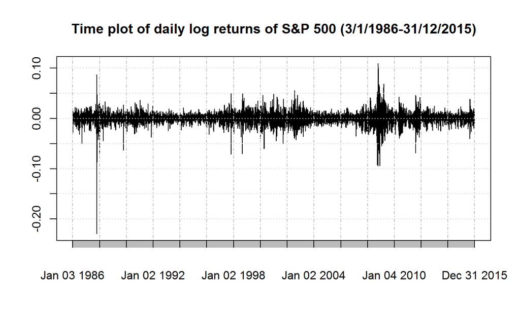

## 1. Specify a Mean Equation

- Build an ARMA model for the mean equation to remove any linear dependence

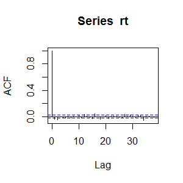

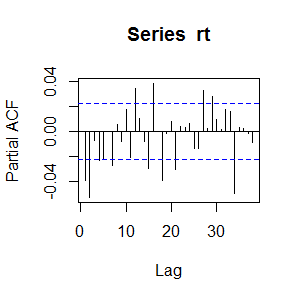

- Both tail off to zero after lag 2
- Specify an ARMA(1,1) model to remove the linear dependence

```
##  Box-Ljung test
## data:  resid(arma)
## X-squared = 11.103, df = 9, p-value = 0.2687
```

- p-value > 0.05
  - Conclude that the series does not have significant serial correlations

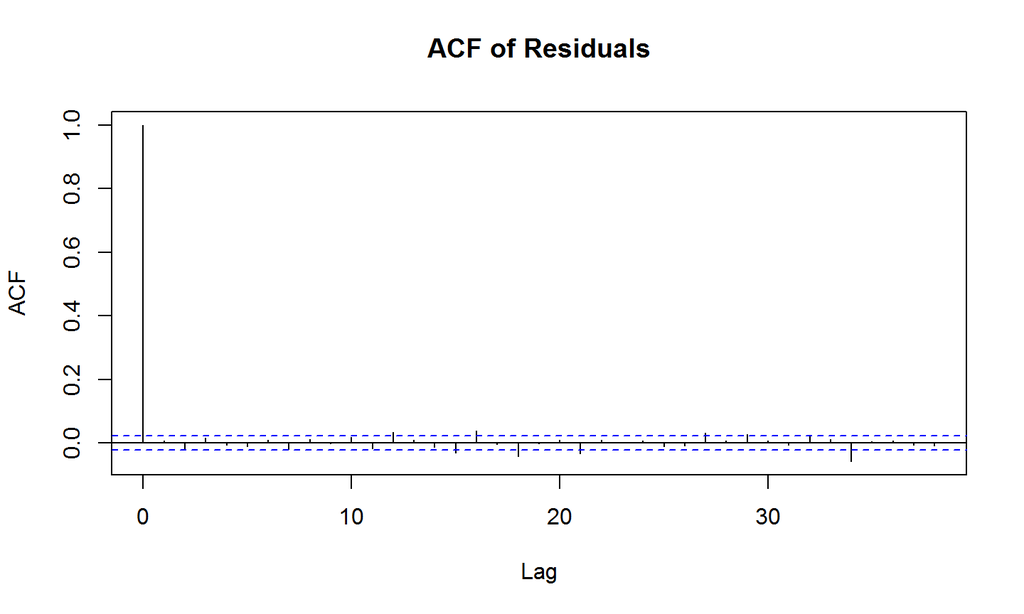

## 2. Test for ARCH Effects

- Use the squared residuals of the mean equation to test for conditional heteroscedasticity

```
##  Box-Ljung test
##
## data:  resid(arma)^2
## X-squared = 988.18, df = 9, p-value < 2.2e-16
```

- p-value is close to 0
  - There are serial correlations in the squared residuals
  - The data shows strong ARCH effects

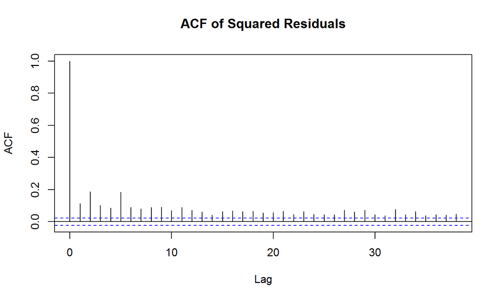

- ARCH effects are statistically significant
  - The S&P 500 data can be used as examples to build volatility models

## Model Building: GARCH

## 1. Joint Estimation of ARMA(p,q)-GARCH(1,1)

- Assume normal innovations
- ARMA(p,q) with \(p\in\{0,1,2\}\) and \(q\in\{0,1,2\}\) are fitted for the mean equation
- Models with all statistically significant coefficients:
  - GARCH(1,1)
  - ARMA(1,1)-GARCH(1,1)
  - ARMA(2,2)-GARCH(1,1)

## 2. Fit Other Conditional Distributions for Innovations

- To model the excess kurtosis
- Re-estimate the models with:
  - the Student Distribution
  - the Generalized Error Distribution (GED)

## 3. Check the Models

- The Ljung-Box test on standardized residuals {\(\tilde{\epsilon}_t\)}
  - \(H_0\): adequate mean equation
- The Ljung-Box test on standardized squared residuals {\(\tilde{\epsilon}_t^2\)}
  - \(H_0\): adequate volatility equation
- If p-values > 0.05
  - Conclude that the mean equation and volatility equation are adequate
- For example: GARCH(1,1)-Normal

```
## Weighted Ljung-Box Test on Standardized Residuals
## ------------------------------------
##                         statistic p-value
## Lag[1]                     0.1276  0.7209
## Lag[2*(p+q)+(p+q)-1][2]    0.5523  0.6696
## Lag[4*(p+q)+(p+q)-1][5]    4.8942  0.1617
## d.o.f=0
## H0 : No serial correlation

## Weighted Ljung-Box Test on Standardized Squared Residuals
## ------------------------------------
##                         statistic p-value
## Lag[1]                     0.2358  0.6273
## Lag[2*(p+q)+(p+q)-1][5]    1.7062  0.6892
## Lag[4*(p+q)+(p+q)-1][9]    2.3802  0.8551
## d.o.f=2
```

- Models that are adequate in describing the linear dependence in the return and volatility series:
  - GARCH(1,1)-Normal
  - GARCH(1,1)-GED
  - ARMA(2,2)-GARCH(1,1)-Normal

## 4. Choose the Best Fitted Model

|  | AIC |
| --- | --- |
| GARCH(1,1)-Normal | -6.4798 |
| GARCH(1,1)-GED | -6.5426 |
| ARMA(2,2)-GARCH(1,1)-Normal | -6.4828 |

- Smaller AIC = Better fitted
  - GARCH(1,1)-GED is the best among GARCH(1,1) models
- The estimation of the GARCH(1,1)-GED gives

\[ \begin{align*} y_{t} &= 0.0006739221+\epsilon_t, \\ \epsilon_t &= \sqrt{h_t}w_t, \\ h_t &= 1.177207\times10^{-6} + 0.07872246 \epsilon_{t-1}^2 + 0.9129511 h_{t-1} \end{align*} \]

- Strong persistence:

\[ \begin{align*} \hat{p} &= \alpha_1 + \beta_1 \\ &= 0.9916736 \end{align*} \]

- The unconditional variance:

\[ \begin{align*} \hat{\sigma}^2 &= \frac{\omega}{1-\hat{p}} \\ &= 0.0001413818 \end{align*} \]

## Model Building: GARCH-M

## 1. Choose an Appropriate Mean Equation

- Fit both

\[y_t = \mu + c\sqrt{h_t} + \epsilon_t\] \[y_t = \mu + ch_t + \epsilon_t\]

- \(y_t = \mu + ch_t + \epsilon_t\) is better
  - All coefficients are statistically significant

## 3. Check the Models

- Use Ljung-Box test on {\(\tilde{\epsilon}_t\)} and {\(\tilde{\epsilon}_t^2\)}
- GARCH(1,1)-M-Normal and GARCH(1,1)-M-GED are both adequate in describing the linear dependence in the return and volatility series
- For GARCH(1,1)-M-Normal:

```
## Weighted Ljung-Box Test on Standardized Residuals
## ------------------------------------
##                         statistic p-value
## Lag[1]                     0.2000  0.6547
## Lag[2*(p+q)+(p+q)-1][2]    0.5147  0.6867
## Lag[4*(p+q)+(p+q)-1][5]    4.1118  0.2404
## d.o.f=0
## H0 : No serial correlation

## Weighted Ljung-Box Test on Standardized Squared Residuals
## ------------------------------------
##                         statistic p-value
## Lag[1]                     0.1325  0.7158
## Lag[2*(p+q)+(p+q)-1][5]    1.4932  0.7416
## Lag[4*(p+q)+(p+q)-1][9]    2.1178  0.8905
## d.o.f=2
```

- For GARCH(1,1)-M-GED:

```
## Weighted Ljung-Box Test on Standardized Residuals
## ------------------------------------
##                         statistic p-value
## Lag[1]                     0.1595  0.6896
## Lag[2*(p+q)+(p+q)-1][2]    0.5386  0.6758
## Lag[4*(p+q)+(p+q)-1][5]    4.5113  0.1968
## d.o.f=0
## H0 : No serial correlation

## Weighted Ljung-Box Test on Standardized Squared Residuals
## ------------------------------------
##                         statistic p-value
## Lag[1]                      1.599   0.206
## Lag[2*(p+q)+(p+q)-1][5]     4.411   0.207
## Lag[4*(p+q)+(p+q)-1][9]     5.092   0.416
## d.o.f=2
```

## 4. Choose the Best Fitted Model

|  | AIC |
| --- | --- |
| GARCH(1,1)-M-Normal | -6.4802 |
| GARCH(1,1)-M-GED | -6.5427 |

- GARCH(1,1)-M-GED gives a relatively smaller AIC
  - Better in describing the linear dependence in the return and volatility series
- The estimation of the GARCH(1,1)-M-GED gives

\[ \begin{align*} y_t &= 0.000520 + 2.225064h_t + \epsilon_t, \\ \epsilon_t &= \sqrt{h_t}w_t, \\ h_t &= 0.000001 + 0.079698 \epsilon_{t-1}^2 + 0.911536 h_{t-1} \end{align*} \]

## Model Building: Stochastic Volatility

## 1. Prepare the Data

- The data should be demeaned to avoid zero returns
  - To keep away from numerical errors

## 2. Specify Prior Distributions

- For the level parameter \(\mu\):

  \[\mu\sim\mathcal{N}(-10,5)\]
- For the persistence parameter \(\phi\):

  \[\frac{(\phi+1)}{2}\sim Beta(20,1.5)\]
  - The prior expectation is 0.8604651
  - The prior variance is 0.01153777
- For the volatility of the log-volatility \(\sigma\):

  \[\sigma^2 \sim Gamma(\frac{1}{2}, \frac{1}{2})\]

## 3. Run the Sampler

- Burn-in period: 1000 iterations
- MCMC: 10000 draws

## 4. Assess the Output and Display the Results

```
## Summary of 10000 MCMC draws after a burn-in of 1000.
##
## Prior distributions:
## mu        ~ Normal(mean = -10, sd = 5)
## (phi+1)/2 ~ Beta(a0 = 20, b0 = 1.5)
## sigma^2   ~ 1 * Chisq(df = 1)

## Posterior draws of parameters (thinning = 1):
##              mean      sd     5%     50%     95%  ESS
## mu        -9.4697 0.11486 -9.659 -9.4690 -9.2846 7300
## phi        0.9817 0.00318  0.976  0.9818  0.9867  247
## sigma      0.1746 0.01248  0.155  0.1747  0.1955  137
## exp(mu/2)  0.0088 0.00051  0.008  0.0088  0.0096 7300
## sigma^2    0.0306 0.00438  0.024  0.0305  0.0382  137
```

- The estimation of the stochastic volatility gives

\[ \begin{align*} y_t &= e^{h_t/2}\epsilon_t,\\ h_{t} &= -9.4697+0.9817(h_{t-1}+9.4697)+0.1746\eta_t\\ \end{align*} \]

- The posterior mean of \(\phi\) is close to 1
  - Suggests a strong daily volatility persistence

## 5. Check the Model

- Stochastic volatility:
  - Nonlinear
  - Involve latent variables
- Infeasible to use standard diagnostic approaches to investigate the properties of residuals
  - Due to the latent dimension of stochastic volatility
- Check the convergence of the MCMC by trace plots and density plots
- Assess the model fit by Quantile-Quantile Plot

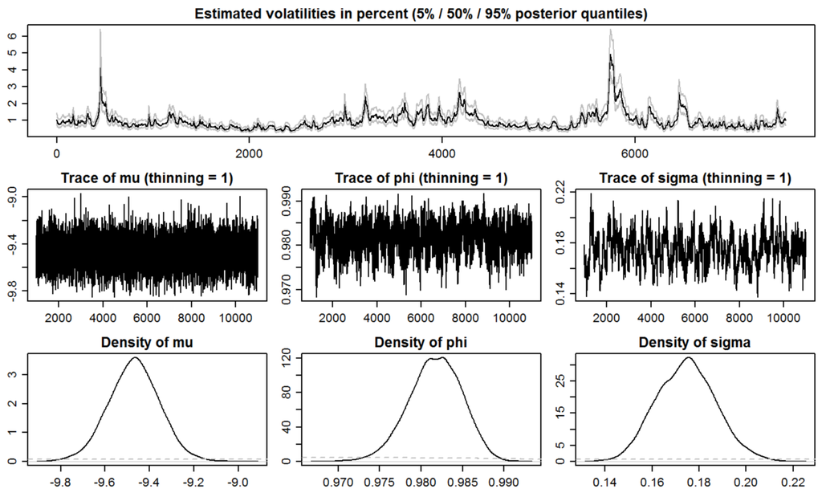

- Concentrated around the means
  - Indicates good mixing of the Markov chain

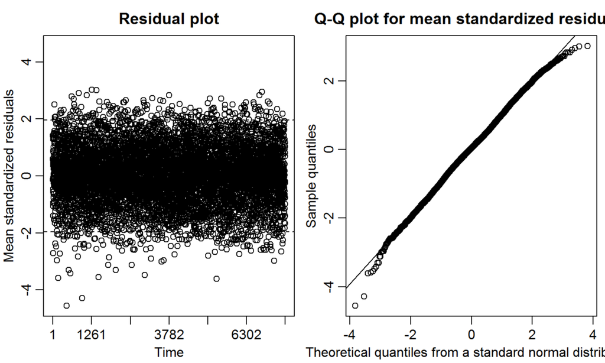

- Few outliers
  - The Q-Q plot suggests a good fit

## Comparsion between GARCH & SV

## Difference between GARCH & SV

GARCH model:

- One white noise driving both conditional mean and conditional volatility
- Estimation of parameters \((\mu,\omega,\alpha,\beta)\)
  - By maximizing the log likelihood

Stochastic volatility model:

- Separate white noises driving the conditional mean and conditional volatility
  - Provides a more realistic and flexible model
  - A lot harder to estimate
- Estimation of parameters \((\mu,\phi,\sigma)\)
  - By Markov chain Monte Carlo (MCMC)

## Best Model for the S&P 500 Index

- Measure the predictive accuracy by MAE and MSE
- The true underlying volatility process is unobservable
  - \((y_t-\bar{y})^2\) is a proxy for the latent volatility

\[MAE=\frac{1}{N}\sum_{n=1}^{N}|(y_{t+n}-\bar{y})^2-\hat{h}_{t+n}|\]

\[MSE=\frac{1}{N}\sum_{n=1}^{N}[(y_{t+n}-\bar{y})^2-\hat{h}_{t+n}]^2\]

- \(y_{t+n}\) is the asset return for \(n\)-steps ahead
- \(\bar{y}\) is the mean of return
- \(\hat{h}_{t+n}\) is the \(n\)-steps ahead forecasted volatility
- \(39\)-days ahead volatility forecasts

|  | AIC | MAE | MSE |
| --- | --- | --- | --- |
| GARCH(1,1)-Normal | -6.4798 | 0.01052951 | 0.0001109536 |
| GARCH(1,1)-GED | -6.5426 | 0.0104425 | 0.0001091059 |
| ARMA(2,2)-GARCH(1,1)-Normal | -6.4828 | 0.01047596 | 0.00010983 |
| GARCH(1,1)-M-Normal | -6.4802 | 0.01053643 | 0.000111102 |
| GARCH(1,1)-M-GED | -6.5427 | 0.01044014 | 0.0001090564 |
| Stochastic Volatility | N/A | 0.009510463 | 0.00009049601 |

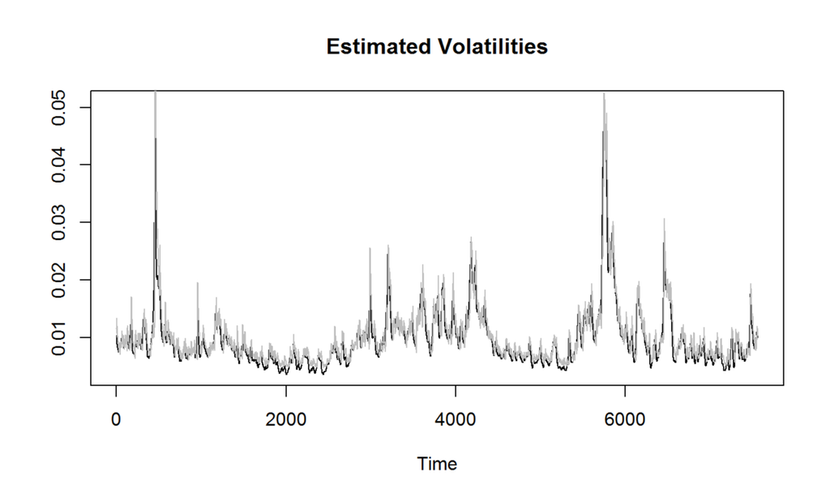

- Black line: SV
- Gray line: GARCH(1,1)-M-GED
  - The patterns are similar

## Conclusion

## Aim of the Project

- Study volatility models:
  - GARCH, GARCH-M & stochastic volatility
- Apply to real data
  - Procedure of model estimation
  - Application workflow

## Results from the S&P 500 Analysis

- GED is better than the normal distribution and the Student Distribution in GARCH models
- GARCH-M models the data better than GARCH
  - The conditional variance can impact the mean of future returns
- SV provides better out-of-sample forecast performance than all GARCH-type models

## Problems

- GARCH-type models are more frequently used than SV
  - SV: takes a long time to compute the MCMC algorithm (~3 min)
  - GARCH-type: computes the MLE quickly (~1-2 s)
- The additional predictive accuracy of SV is not that attractive to people
  - Especially in the case of analyzing multiple large data sets